# Lab1AnalisisPCA

### Diesel

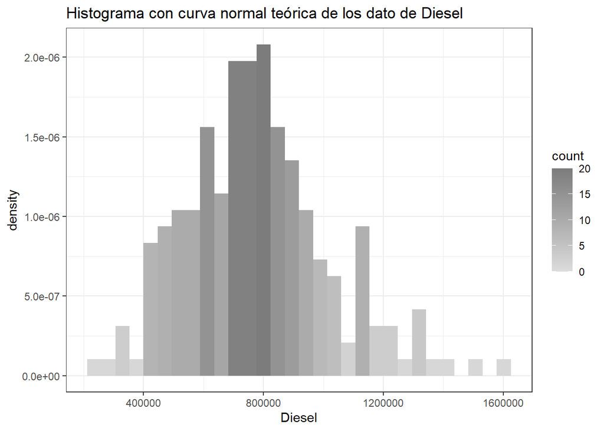

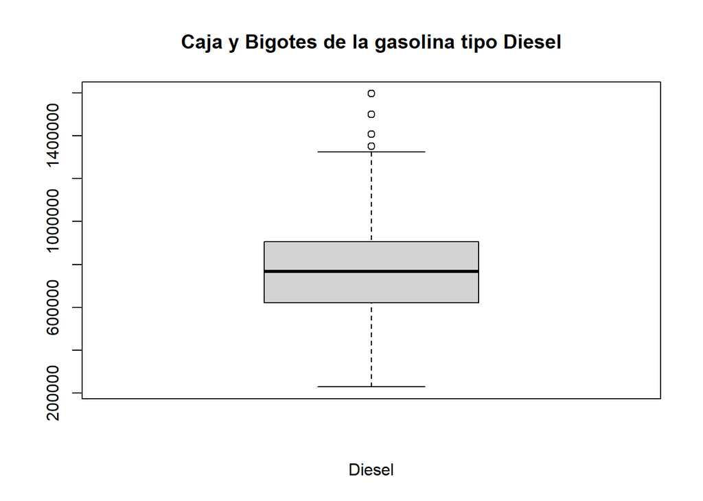

Observando el diagrama de caja y bigotes se puede ver que muchos datos si cumplen con el supuesto de normalidad, sin contar los 4 puntos sobre el cuartil, si parece cumplir normalidad.

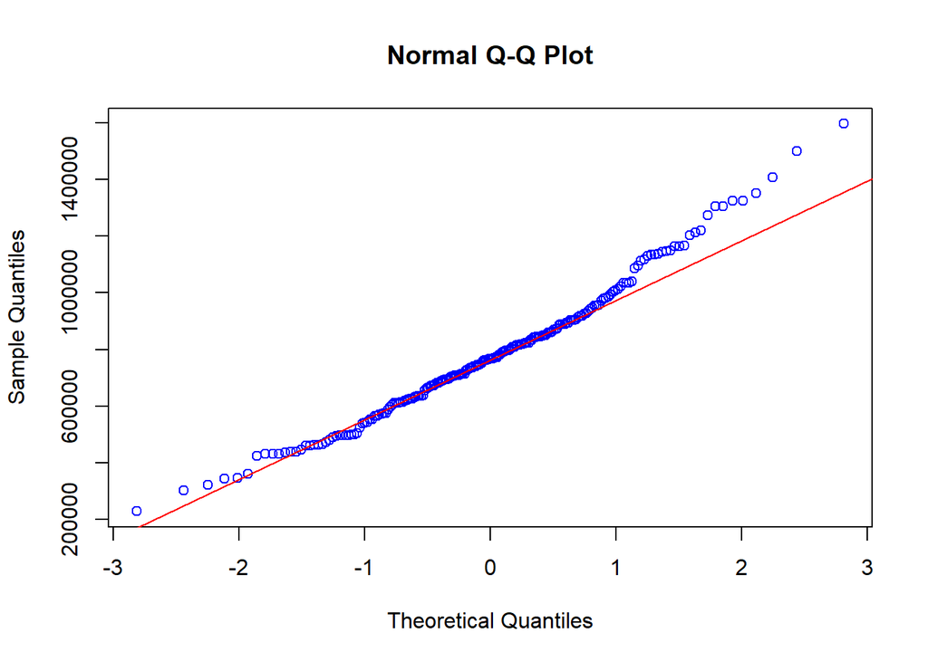

### DieselLS

[figure not shown]

Por último, debido a que, como dicho anteriormente, fue hasta el 2017 que se utilizó Diesel “normal” y se comenzó a utilizar el 2018 Diesel bajo en azufre. En su histograma se puede ver que efectivamente parece seguir una distribución normal, además de no presentar sesgos significativos.

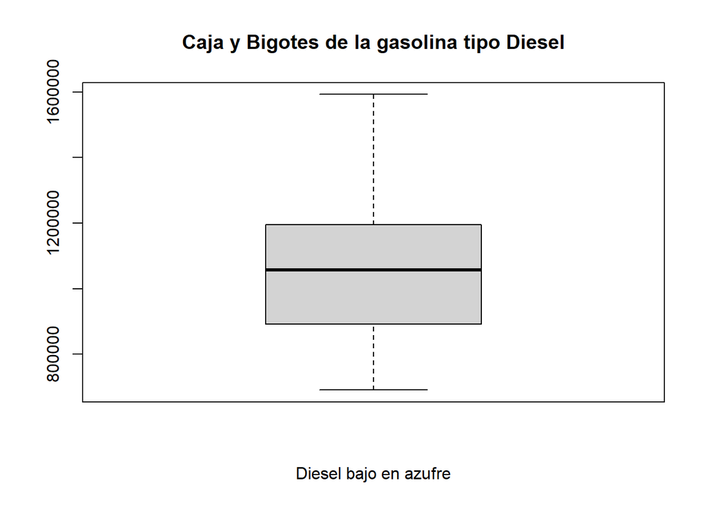

En el diagrama de caja y bigotes se puede observar que no hay ningún punto atípico, además de que los cuartiles si parecen seguir normalidad.

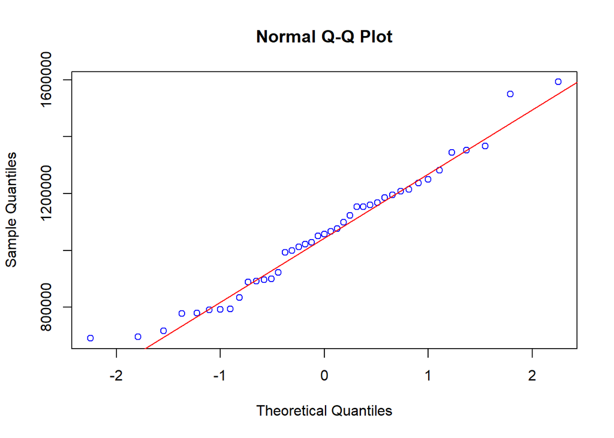

Por último, en el diagrama QQ normal se puede observar que los datos si siguen la linea de tendencia (son pocos debido a que solo han sido almacenados 4 años) y por lo tanto si cumplen con normalidad.